# Estimador Sintético

Christian Castro

2024-10-22

# 1 1 Estimadoresmuestrales

## 1.1 Estimadores basados en el diseño

Estimadores directos

Los estimadores directos basados en el diseño (design-based) consideran las propiedades del diseño muestral para realizar la estimación de algún parámetro de interés como el total o la media. El estimador Horvitz y Thompson es el estimador basado en el diseño más conocido, el cual se basa solamente en las probabilidades de inclusión en la muestra.

## 1.2 El estimador de Horvitz-Thompson (HT)

El estimador de HT se utiliza para estimar el total o la media de una variable de interés en una población a partir de una muestra. Es particularmente útil en situaciones donde las unidades de la población tienen diferentes probabilidades de ser incluidas en la muestra, lo que se conoce como muestreo con probabilidades desiguales.

El estimador de HT ajusta los valores de la muestra según las probabilidades de inclusión de cada unidad. Esto se hace para corregir cualquier sesgo que pueda surgir debido a las diferentes probabilidades de inclusión.

Consideramos una población finita U de tamaño N, donde yi, i ϵ U son los valores de la variable de interés en la población. A través de una muestra k ϵ U tomada de la población U deseamos obtener un estadístico que se aproxime al valor del total poblacional Y.

La fórmula del estimador de Horvitz-Thompson para el total de la población es:

$$\hat{\tau}_{HT} = \sum_{i \in s} \frac{y_i}{\pi_i}$$
Donde:

$\hat{\tau}_{HT}$ es el estimador de Horvitz-Thompson para el total.  
$s$ es la muestra.  
$y_i$ es el valor de la variable de interés para la unidad $i$.  
$\pi_i$ es la probabilidad de inclusión de la unidad $i$ en la muestra.

La varianza del estimador de Horvitz-Thompson se define como:

$$\text{Var}(\hat{\tau}_{HT}) = \sum_{i \in U} \sum_{j \in U} \left(
\frac{\pi_{ij} - \pi_i \pi_j}{\pi_{ij}} \right) \frac{y_i y_j}{\pi_i
\pi_j}$$

### 1.2.1 Ejemplo en R

Tenemos una población de 100 registros. Listamos los tres primeros y tres últimos elementos.

```
##    ID        y
## 1   1 44.39524
## 2   2 47.69823
## 3   3 65.58708
## 4  98 65.32611
## 5  99 47.64300
## 6 100 39.73579
```

Listamos la probabilidad de inclusion en la lista

```r
pik
```

```
##   [1] 0.1744271 0.1874044 0.2576890 0.1992182 0.2015277 0.2638322 0.2145572
##   [8] 0.1467442 0.1694618 0.1789381 0.2445417 0.2105849 0.2121941 0.2007967
##  [15] 0.1746092 0.2666551 0.2160083 0.1191804 0.2240040 0.1778722 0.1544936
##  [22] 0.1878838 0.1561367 0.1678101 0.1718904 0.1301785 0.2293643 0.2024740
##  [29] 0.1517310 0.2457099 0.2132036 0.1848547 0.2316171 0.2309495 0.2287276
##  [36] 0.2235044 0.2182112 0.1940155 0.1844268 0.1814994 0.1691532 0.1882790
##  [43] 0.1467311 0.2816654 0.2439083 0.1523215 0.1806188 0.1781133 0.2270925
##  [50] 0.1931725 0.2064008 0.1953264 0.1947636 0.2502198 0.1875775 0.2560295
##  [57] 0.1355981 0.2194172 0.2013142 0.2049322 0.2113639 0.1767119 0.1833564
##  [64] 0.1564286 0.1543377 0.2083735 0.2140580 0.1985305 0.2326835 0.2769950
##  [71] 0.1771556 0.1057217 0.2359631 0.1685838 0.1694164 0.2367423 0.1852594
##  [78] 0.1484865 0.2035713 0.1909910 0.1966745 0.2115855 0.1818849 0.2217653
##  [85] 0.1877852 0.2094836 0.2395424 0.2135461 0.1836423 0.2415842 0.2354824
##  [92] 0.2179943 0.2058277 0.1717778 0.2499075 0.1728640 0.2823874 0.2566636
##  [99] 0.1871874 0.1561203
```

Listamos los indices de los elementos elegidos

```r
sample_indices
```

```
##   [1] 0 0 0 0 0 0 0 0 0 1 0 0 0 0 1 0 0 0 0 0 0 0 0 0 1 0 0 0 0 0 0 0 0 1 0 0 1
##  [38] 0 1 0 0 0 0 0 0 0 0 0 0 0 0 0 0 0 0 0 0 0 0 0 0 0 0 0 0 0 0 0 1 0 0 1 1 1
##  [75] 0 0 0 0 1 0 0 1 0 0 1 0 1 0 1 0 0 1 1 0 0 0 0 1 1 0
```

Listamos los tres primeros y tres últimos elementos de las muestras seleccionadas

```r
library(dplyr)
head_rows <- head(sample, 3)
tail_rows <- tail(sample, 3)
sample <- bind_rows(head_rows, tail_rows)
sample
```

```
##   ID        y
## 1 10 45.54338
## 2 15 44.44159
## 3 25 43.74961
## 4 93 52.38732
## 5 98 65.32611
## 6 99 47.64300
```

Calculamos la suma total de toda la población:

```r
# Calcular la suma de la columna y
total_y <- sum(population$y)
# Mostrar el resultado
total_y
```

```
## [1] 5090.406
```

Vemos nuestro estimador HT:

```r
# Mostrar el resultado
HT_estimate
```

```
##          [,1]
## [1,] 4835.886
```

## 1.3 Estimadores basados en el modelo

Por otro lado, los estimadores basados en el modelo llamados también estimadores indirectos son sumamente útiles cuando el tamaño de muestra de algunos dominios o subpoblaciones son pequeños por lo que se utiliza información auxiliar de otros dominios para mejorar la precisión de las estimaciones. Entre los tipos de estimadores indirectos se encuentran los estimadores sintéticos y estimadores compuestos.

Estimadores sintéticos

Los estimadores sintéticos se caracterizan por derivar un **estimador indirecto para un área pequeña** bajo el supuesto de que las áreas pequeñas tienen las mismas características que el área para el cual se tiene información auxiliar.Entre los estimadores sintéticos se encuentran los derivados del modelo sin información auxiliar (Area level auxiliary information), modelo con información auxiliar a nivel de área (area level auxiliary information) y modelo con información auxiliar a nivel de unidad (unit level auxiliary information). Como ejemplo, definiremos el modelo con información auxiliar a nivel de área definido por Rao y Molina(2015).

### 1.3.1 Fórmula del modelo de regresión lineal con información auxiliar a nivel de área.

$$\tilde{Y}_i = \beta_0 + \beta_1 x_{i1} + \beta_2 x_{i2} + \cdots +
\beta_p x_{ip}, \quad i = 1, \ldots, m$$

Donde:

$$\begin{array}{l}
\tilde{Y}_i : \text{Estimación del área pequeña } i \\
\beta_0 : \text{Intercepto del modelo} \\
\beta_1, \beta_2, \ldots, \beta_p : \text{Coeficientes de regresión
para las covariables} \\
x_{i1}, x_{i2}, \ldots, x_{ip} : \text{Covariables auxiliares para el
área } i \\
i : \text{Índice del área pequeña, donde } i = 1, \ldots, m \\
m : \text{Número total de áreas pequeñas}
\end{array}$$

Los coeficientes de regresión estimados ($\beta_0, \hat{\beta}_1, \ldots, \hat{\beta}_p$) facilitan la obtención de predictores sintéticos de regresión para todas las n áreas, los cuales están dados por

$$\hat{\tilde{Y}_i} = \mathbf{x}_i^\top \hat{\beta}, \quad i = 1, \ldots,
n$$

```r
# Crear un conjunto de datos de ejemplo
set.seed(123)
n <- 10  # Número de áreas
p <- 3   # Número de covariables

# Generar covariables auxiliares
x <- matrix(rnorm(n * p), nrow = n, ncol = p)
colnames(x) <- paste0("x", 1:p)

# Coeficientes de regresión verdaderos
beta <- c(2, -1, 0.5, 1.5)

# Generar la variable de interés
y <- beta[1] + x %*% beta[-1] + rnorm(n)

# Crear un data frame
data <- data.frame(y = y, x)

# Ajustar el modelo de regresión lineal
model <- lm(y ~ ., data = data)

# Obtener los coeficientes estimados
beta_hat <- coef(model)

# Calcular el estimador sintético para cada área
y_tilde <- beta_hat[1] + as.matrix(data[, -1]) %*% beta_hat[-1]

# Mostrar los resultados
data.frame(Area = 1:n, Estimacion_Sintetica = y_tilde)
```

```
##    Area Estimacion_Sintetica
## 1     1            1.5791452
## 2     2            2.2159224
## 3     3            0.1083548
## 4     4            1.2863044
## 5     5            1.1703309
## 6     6           -0.3989350
## 7     7            3.2354495
## 8     8            2.5584220
## 9     9            1.3914973
## 10   10            4.0024242
```

```r
data
```

```
##             y          x1         x2         x3
## 1   1.9972452 -0.56047565  1.2240818 -1.0678237
## 2   1.7880505 -0.23017749  0.3598138 -0.2179749
## 3  -0.0022036  1.55870831  0.4007715 -1.0260044
## 4   1.7696296  0.07050839  0.1106827 -0.7288912
## 5   1.4768139  0.12928774 -0.5558411 -0.6250393
## 6  -0.6630081  1.71506499  1.7869131 -1.6866933
## 7   3.5986073  0.46091621  0.4978505  0.8377870
## 8   2.4499006 -1.26506123 -1.9666172  0.1533731
## 9   1.0243627 -0.68685285  0.7013559 -1.1381369
## 10  3.7095176 -0.44566197 -0.4727914  1.2538149
```

## 1.4 Ejemplo de Estimador Sintético

Supongamos que tenemos un modelo con $n = 3$ áreas y $p = 2$ covariables. Los datos y los coeficientes estimados son los siguientes:

1. **Covariables auxiliares ($\mathbf{X}$)**:
   $$\mathbf{X} = \begin{pmatrix}
   1 & x_{11} & x_{12} \\
   1 & x_{21} & x_{22} \\
   1 & x_{31} & x_{32}
   \end{pmatrix}
   = \begin{pmatrix}
   1 & 2 & 3 \\
   1 & 4 & 5 \\
   1 & 6 & 7
   \end{pmatrix}$$
2. **Coeficientes estimados ($\hat{\beta}$)**:
   $$\hat{\beta} = \begin{pmatrix}
   \hat{\beta}_0 \\
   \hat{\beta}_1 \\
   \hat{\beta}_2
   \end{pmatrix}
   = \begin{pmatrix}
   0.5 \\
   1.0 \\
   1.5
   \end{pmatrix}$$
3. **Estimador sintético ($\hat{\tilde{Y}_i}$)**:
   $$\hat{\tilde{Y}_i} = \mathbf{x}_i^\top \hat{\beta}, \quad i = 1, \ldots,
   3$$

Calculamos $\hat{\tilde{Y}_i}$ para cada área:

- Para $i = 1$:
  $$\hat{\tilde{Y}_1} = \begin{pmatrix}
  1 & 2 & 3
  \end{pmatrix}
  \begin{pmatrix}
  0.5 \\
  1.0 \\
  1.5
  \end{pmatrix}
  = 1 \cdot 0.5 + 2 \cdot 1.0 + 3 \cdot 1.5 = 0.5 + 2 + 4.5 = 7$$
- Para $i = 2$:
  $$\hat{\tilde{Y}_2} = \begin{pmatrix}
  1 & 4 & 5
  \end{pmatrix}
  \begin{pmatrix}
  0.5 \\
  1.0 \\
  1.5
  \end{pmatrix}
  = 1 \cdot 0.5 + 4 \cdot 1.0 + 5 \cdot 1.5 = 0.5 + 4 + 7.5 = 12$$
- Para $i = 3$:
  $$\hat{\tilde{Y}_3} = \begin{pmatrix}
  1 & 6 & 7
  \end{pmatrix}
  \begin{pmatrix}
  0.5 \\
  1.0 \\
  1.5
  \end{pmatrix}
  = 1 \cdot 0.5 + 6 \cdot 1.0 + 7 \cdot 1.5 = 0.5 + 6 + 10.5 = 17$$

Así, las estimaciones sintéticas para las tres áreas son:
$$\hat{\tilde{Y}_1} = 7, \quad \hat{\tilde{Y}_2} = 12, \quad
\hat{\tilde{Y}_3} = 17$$

## 1.5 Ejemplo de Estimador Sintético

Supongamos que tenemos un modelo con $n = 3$ áreas y $p = 2$ covariables. Los datos y los coeficientes estimados son los siguientes:

1. **Covariables auxiliares ($\mathbf{X}$)**:
   $$\mathbf{X} = \begin{pmatrix}
   1 & x_{11} & x_{12} \\
   1 & x_{21} & x_{22} \\
   1 & x_{31} & x_{32}
   \end{pmatrix}
   = \begin{pmatrix}
   1 & 2 & 3 \\
   1 & 4 & 5 \\
   1 & 6 & 7
   \end{pmatrix}$$
2. **Coeficientes estimados ($\hat{\beta}$)**:
   $$\hat{\beta} = \begin{pmatrix}
   \hat{\beta}_0 \\
   \hat{\beta}_1 \\
   \hat{\beta}_2
   \end{pmatrix}
   = \begin{pmatrix}
   0.5 \\
   1.0 \\
   1.5
   \end{pmatrix}$$
3. **Estimador sintético ($\hat{\tilde{Y}_i}$)**:
   $$\hat{\tilde{Y}_i} = \mathbf{x}_i^\top \hat{\beta}, \quad i = 1, \ldots,
   3$$

Calculamos $\hat{\tilde{Y}_i}$ para cada área:

- Para $i = 1$:
  $$\hat{\tilde{Y}_1} = \begin{pmatrix}
  1 & 2 & 3
  \end{pmatrix}
  \begin{pmatrix}
  0.5 \\
  1.0 \\
  1.5
  \end{pmatrix}
  = 1 \cdot 0.5 + 2 \cdot 1.0 + 3 \cdot 1.5 = 0.5 + 2 + 4.5 = 7$$
- Para $i = 2$:
  $$\hat{\tilde{Y}_2} = \begin{pmatrix}
  1 & 4 & 5
  \end{pmatrix}
  \begin{pmatrix}
  0.5 \\
  1.0 \\
  1.5
  \end{pmatrix}
  = 1 \cdot 0.5 + 4 \cdot 1.0 + 5 \cdot 1.5 = 0.5 + 4 + 7.5 = 12$$
- Para $i = 3$:
  $$\hat{\tilde{Y}_3} = \begin{pmatrix}
  1 & 6 & 7
  \end{pmatrix}
  \begin{pmatrix}
  0.5 \\
  1.0 \\
  1.5
  \end{pmatrix}
  = 1 \cdot 0.5 + 6 \cdot 1.0 + 7 \cdot 1.5 = 0.5 + 6 + 10.5 = 17$$

Así, las estimaciones sintéticas para las tres áreas son:
$$\hat{\tilde{Y}_1} = 7, \quad \hat{\tilde{Y}_2} = 12, \quad
\hat{\tilde{Y}_3} = 17$$

## 1.6 Significado de la Transpuesta

La transpuesta en $\mathbf{x}_i^\top \hat{\beta}$ se refiere a la operación de transposición aplicada al vector $\mathbf{x}_i$. Aquí te explico cada componente:

1. **Vector de covariables ($\mathbf{x}_i$)**:
   $$\mathbf{x}_i = \begin{pmatrix}
   x_{i1} \\
   x_{i2} \\
   \vdots \\
   x_{ip}
   \end{pmatrix}$$
   Este es un vector columna que contiene las covariables auxiliares para el área $i$-ésima.
2. **Transpuesta del vector ($\mathbf{x}_i^\top$)**:
   $$\mathbf{x}_i^\top = \begin{pmatrix}
   x_{i1} & x_{i2} & \cdots & x_{ip}
   \end{pmatrix}$$
   La transposición convierte el vector columna en un vector fila.
3. **Coeficientes estimados ($\hat{\beta}$)**:
   $$\hat{\beta} = \begin{pmatrix}
   \hat{\beta}_1 \\
   \hat{\beta}_2 \\
   \vdots \\
   \hat{\beta}_p
   \end{pmatrix}$$
   Este es un vector columna que contiene los coeficientes estimados del modelo de regresión.
4. **Producto escalar ($\mathbf{x}_i^\top \hat{\beta}$)**:
   $$\mathbf{x}_i^\top \hat{\beta} = \begin{pmatrix}
   x_{i1} & x_{i2} & \cdots & x_{ip}
   \end{pmatrix}
   \begin{pmatrix}
   \hat{\beta}_1 \\
   \hat{\beta}_2 \\
   \vdots \\
   \hat{\beta}_p
   \end{pmatrix}
   = x_{i1} \hat{\beta}_1 + x_{i2} \hat{\beta}_2 + \cdots + x_{ip}
   \hat{\beta}_p$$
   Este producto escalar da como resultado un valor escalar que es la estimación sintética $\hat{\tilde{Y}_i}$ para el área $i$-ésima.

# 2 2 Modelos lineales mixtos

$$\mathbf{y} =
\mathbf{X}\boldsymbol{\beta} + \mathbf{Z}\mathbf{u} +
\boldsymbol{\epsilon}$$
$$\begin{array}{l}
\mathbf{y} : \text{es el vector de respuestas (n x 1) } \\
\mathbf{X} : \text{es la matriz de diseño para los efectos fijos (n x
p)} \\
\boldsymbol{\beta} : \text{es el vector de coeficientes de efectos
fijos (p x 1)} \\
\mathbf{Z} : \text{es la matriz de diseño para los efectos aleatorios
(n x q) } \\
\mathbf{u} : \text{es el vector de efectos aleatorios (q x 1)}, donde
\mathbf{u} \sim \mathcal{N}(\mathbf{0}, \mathbf{G}) \\
\boldsymbol{\epsilon}: \text{es el vector de errores (n x 1)}, donde
\boldsymbol{\epsilon} \sim \mathcal{N}(\mathbf{0}, \mathbf{R})
\end{array}$$
La matriz de covarianza de
$$\mathbf{y}$$
es:

$$\mathbf{V} =
\mathbf{Z}\mathbf{G}\mathbf{Z}^\top + \mathbf{R}$$

Los modelos lineales mixtos son una extensión de los modelos de regresión lineal clásicos. Se utilizan para analizar datos que tienen una estructura jerárquica o de agrupamiento, lo que es común en estudios longitudinales y en investigaciones donde las observaciones están agrupadas en diferentes niveles (por ejemplo, estudiantes dentro de escuelas, pacientes dentro de hospitales).

Características Principales Efectos Fijos y Aleatorios: Efectos Fijos: Son los mismos para todas las unidades de análisis y representan la relación promedio entre las variables independientes y la variable dependiente. Efectos Aleatorios: Varían entre las unidades de análisis y permiten capturar la variabilidad no explicada por los efectos fijos. Estos efectos ayudan a modelar la heterogeneidad en los datos. Matriz de Covarianzas: Los modelos lineales mixtos utilizan una matriz de covarianzas para modelar la estructura de correlación entre las observaciones. Esto es especialmente útil en datos longitudinales donde las observaciones repetidas de un mismo sujeto están correlacionadas. Aplicaciones Comunes Estudios Longitudinales: Para analizar datos donde las mismas unidades (como individuos) son observadas en múltiples momentos en el tiempo. Investigación Educativa: Para estudiar el rendimiento escolar de estudiantes dentro de diferentes escuelas. Investigación Psicológica: Para analizar comportamientos o bienestar de individuos dentro de diferentes contextos.

Vamos a crear un ejemplo detallado en R que ilustre la formulación algebraica de un modelo lineal mixto. Utilizaremos un conjunto de datos simulado para este propósito.

Paso 1: Crear el Conjunto de Datos

Primero, generamos un conjunto de datos simulado con una estructura jerárquica. Supongamos que tenemos estudiantes (efecto aleatorio) y sus puntajes en un examen (variable dependiente), además de una variable independiente (horas de estudio).

```r
# Instalar y cargar el paquete lme4
# install.packages("lme4")
library(lme4)
# Crear un conjunto de datos simulado
set.seed(123)
n_students <- 30
n_obs_per_student <- 5
total_obs <- n_students * n_obs_per_student

# Variables independientes
students <- factor(rep(1:n_students, each = n_obs_per_student))
hours_studied <- rnorm(total_obs, mean = 5, sd = 2)

# Efectos aleatorios y errores
random_intercepts <- rnorm(n_students, mean = 0, sd = 2)
errors <- rnorm(total_obs, mean = 0, sd = 1)

# Variable dependiente
exam_scores <- 50 + 5 * hours_studied + rep(random_intercepts, each = n_obs_per_student) + errors

# Crear el data frame
data <- data.frame(
  student = students,
  hours_studied = hours_studied,
  exam_scores = exam_scores
)

data
```

```
##     student hours_studied exam_scores
## 1         1     3.8790487    69.90740
## 2         1     4.5396450    75.53689
## 3         1     8.1174166    91.81291
## 4         1     5.1410168    76.41505
## 5         1     5.2585755    77.63208
## 6         2     8.4301300    93.49156
## 7         2     5.9218324    82.25717
## 8         2     2.4698775    63.97221
## 9         2     3.6262943    70.42361
## 10        2     4.1086761    71.58217
## 11        3     7.4481636    88.11967
## 12        3     5.7196277    78.93786
## 13        3     5.8015429    79.76670
## 14        3     5.2213654    75.87587
```

[output cut: 136 more lines]

Paso 2: Ajustar el Modelo Lineal Mixto

Ajustamos el modelo lineal mixto utilizando la función lmer del paquete lme4.

```r
# Ajustar el modelo lineal mixto
modelo <- lmer(exam_scores ~ hours_studied + (1 | student), data = data)

# Resumen del modelo
summary(modelo)
```

```
## Linear mixed model fit by REML ['lmerMod']
## Formula: exam_scores ~ hours_studied + (1 | student)
##    Data: data
##
## REML criterion at convergence: 513
##
## Scaled residuals:
##      Min       1Q   Median       3Q      Max
## -2.62263 -0.56962 -0.09721  0.51101  2.26724
##
## Random effects:
##  Groups   Name        Variance Std.Dev.
##  student  (Intercept) 3.7609   1.9393
##  Residual             0.9613   0.9805
## Number of obs: 150, groups:  student, 30
##
## Fixed effects:
##               Estimate Std. Error t value
## (Intercept)   49.94202    0.42895   116.4
## hours_studied  5.08922    0.04616   110.3
##
## Correlation of Fixed Effects:
##             (Intr)
## hours_studd -0.533
```

Paso 3: Desglose Matemático

Para entender la matemática detrás del modelo, desglosamos las matrices y vectores involucrados:

3.1 Matriz de Diseño para Efectos Fijos $\mathbf{X}$:

Cada fila de $\mathbf{X}$ corresponde a una observación y cada columna a una variable independiente. En nuestro caso, $\mathbf{X}$ incluye una columna de unos (intercepto) y la variable hours_studied.

```r
X <- model.matrix(~ hours_studied, data = data)
head(X)
```

```
##   (Intercept) hours_studied
## 1           1      3.879049
## 2           1      4.539645
## 3           1      8.117417
## 4           1      5.141017
## 5           1      5.258575
## 6           1      8.430130
```

```r
Z <- model.matrix(~ 0 + student, data = data)
head(Z)
```

```
##   student1 student2 student3 student4 student5 student6 student7 student8
## 1        1        0        0        0        0        0        0        0
## 2        1        0        0        0        0        0        0        0
## 3        1        0        0        0        0        0        0        0
## 4        1        0        0        0        0        0        0        0
## 5        1        0        0        0        0        0        0        0
## 6        0        1        0        0        0        0        0        0
##   student9 student10 student11 student12 student13 student14 student15
## 1        0         0         0         0         0         0         0
## 2        0         0         0         0         0         0         0
## 3        0         0         0         0         0         0         0
## 4        0         0         0         0         0         0         0
## 5        0         0         0         0         0         0         0
## 6        0         0         0         0         0         0         0
##   student16 student17 student18 student19 student20 student21 student22
```

[output cut: 20 more lines]

```r
u <- ranef(modelo)$student[,1]
head(u)
```

```
## [1]  0.8586240  1.3398438 -0.2121577 -2.3920813  0.1701011 -0.9330217
```

```r
epsilon <- resid(modelo)
head(epsilon)
```

```
##           1           2           3           4           5           6
## -0.63456753  1.63300696 -0.29902878 -0.54934402  0.06940097 -0.69306675
```

Paso 4: Verificación de la Matriz de Covarianza

$$\mathbf{V} =
\mathbf{Z}\mathbf{G}\mathbf{Z}^\top + \mathbf{R}$$

Podemos verificar esto en R:

```r
# Matriz de covarianza de los efectos aleatorios
n_levels <- length(unique(data$student))
G <- diag(VarCorr(modelo)$student[1], n_levels, n_levels)

# Matriz de covarianza de los errores
R <- diag(attr(VarCorr(modelo), "sc")^2, total_obs)

# Verificar dimensiones
dim(Z)  # Debe ser total_obs x n_levels
```

```
## [1] 150  30
```

```r
dim(G)  # Debe ser n_levels x n_levels
```

```
## [1] 30 30
```

```r
# Matriz de covarianza total
V <- Z %*% G %*% t(Z) + R
head(V)
```

```
##          1        2        3        4        5        6        7        8
## 1 4.722145 3.760856 3.760856 3.760856 3.760856 0.000000 0.000000 0.000000
## 2 3.760856 4.722145 3.760856 3.760856 3.760856 0.000000 0.000000 0.000000
## 3 3.760856 3.760856 4.722145 3.760856 3.760856 0.000000 0.000000 0.000000
## 4 3.760856 3.760856 3.760856 4.722145 3.760856 0.000000 0.000000 0.000000
## 5 3.760856 3.760856 3.760856 3.760856 4.722145 0.000000 0.000000 0.000000
## 6 0.000000 0.000000 0.000000 0.000000 0.000000 4.722145 3.760856 3.760856
##          9       10 11 12 13 14 15 16 17 18 19 20 21 22 23 24 25 26 27 28 29 30
## 1 0.000000 0.000000  0  0  0  0  0  0  0  0  0  0  0  0  0  0  0  0  0  0  0  0
## 2 0.000000 0.000000  0  0  0  0  0  0  0  0  0  0  0  0  0  0  0  0  0  0  0  0
## 3 0.000000 0.000000  0  0  0  0  0  0  0  0  0  0  0  0  0  0  0  0  0  0  0  0
## 4 0.000000 0.000000  0  0  0  0  0  0  0  0  0  0  0  0  0  0  0  0  0  0  0  0
## 5 0.000000 0.000000  0  0  0  0  0  0  0  0  0  0  0  0  0  0  0  0  0  0  0  0
## 6 3.760856 3.760856  0  0  0  0  0  0  0  0  0  0  0  0  0  0  0  0  0  0  0  0
##   31 32 33 34 35 36 37 38 39 40 41 42 43 44 45 46 47 48 49 50 51 52 53 54 55 56
```

[output cut: 41 more lines]

# 3 3 Modelamiento de datos espaciales

# 4 4 Modelo Fay-Herriot

El modelo Fay-Herriot es una variante del modelo lineal mixto, que incluye efectos aleatorios y covariables con información a nivel de área.

Consideremos una población dividida en n áreas pequeñas donde $\theta_i$ representa un parámetro de interés a estimar (ej.total o la media) en el área i-ésima. Además, se asume que $\theta_i$ se relaciona con un vector de $p$ variables auxiliares que dependen de lascaracterísticas del área en mención ${z}_i$ mediante un modelo lineal mixto:

$$\theta_i = \mathbf{z}_i^\top \beta + v_i, \quad i = 1, \ldots, n$$

$$\mathbf{z}_i = \begin{pmatrix}
z_{1i} & z_{2i} & \cdots & z_{pi}
\end{pmatrix}^\top, \quad \boldsymbol{\beta} = \begin{pmatrix}
\beta_1 & \beta_2 & \cdots & \beta_p
\end{pmatrix}^\top$$
Donde:
$$\mathbf{z}_i^\top \beta, \quad i = 1, \ldots, n$$
es el vector de px1 coeficientes de regresion y
$$v_i, \quad i = 1, \ldots, n$$
los efectos aleatorios del area, que se asumen distrubuidos normalmente, ademas de ser independientes es identicamente distribuidos con:
$$E(v_i) = 0, \quad V(v_i) = \sigma^2, \quad v_i \geq 0$$
Ejemplo en R

```r
# Instalar y cargar los paquetes necesarios

library(lme4)
library(dplyr)
library(ggplot2)

# Crear un conjunto de datos de ejemplo
set.seed(123)
n <- 20  # Aumentar el número de observaciones
p <- 3   # Número de covariables

# Generar covariables auxiliares
z <- matrix(rnorm(n * p), nrow = n, ncol = p)
colnames(z) <- paste0("z", 1:p)

# Coeficientes de regresión verdaderos
beta <- c(2, -1, 0.5)

# Generar los efectos aleatorios
sigma_v <- 1
v <- rnorm(n / 2, mean = 0, sd = sigma_v)  # 10 áreas, 2 observaciones por área

# Generar la variable de interés
theta <- z %*% beta + rep(v, each = 2)

# Crear un data frame
data <- data.frame(Area = factor(rep(1:10, each = 2)), theta = theta, z)

# Ajustar el modelo Fay-Herriot
model <- lmer(theta ~ z1 + z2 + z3 + (1 | Area), data = data)
# Obtener los coeficientes estimados
beta_hat <- fixef(model)
v_hat <- ranef(model)$Area[,1]

# # Mostrar los resultados
# results <- data.frame(Area = rep(1:10, each = 2),
#                       Theta = theta,
#                       Estimacion_Sintetica = z %*% beta_hat,
#                       Efecto_Aleatorio = rep(v_hat, each = 2))
# print(results)
#
# # Visualizar los resultados
# ggplot(results, aes(x = Area)) +
#   geom_point(aes(y = Theta), color = "blue", size = 3) +
#   geom_point(aes(y = Estimacion_Sintetica), color = "red", size = 3) +
#   geom_point(aes(y = Efecto_Aleatorio), color = "green", size = 3) +
#   labs(y = "Valores", title = "Modelo Fay-Herriot: Resultados por Área") +
#   theme_minimal() +
#   scale_y_continuous(sec.axis = sec_axis(~ ., name = "Efecto Aleatorio", breaks = v_hat))
```

Estimador BLUP y EBLUP

Para obtener los estimadores de los parámetros del modelo Fay-Herriot y de su variante espacial es necesario derivar un estimador que tenga las propiedades deseadas de insesgamiento y de menor varianza similares al estimador BLUE derivado del **teorema de Gauss-Markov**. En el caso de los modelos lineales mixtos se obtiene el mejor predictor lineal insesgado (BLUP por sus siglas en inglés), el cual minimiza el error cuadrático medio del parámetro de interés.

teorema de Gauss-Markov

El Teorema de Gauss-Markov establece que, bajo ciertos supuestos, el estimador de mínimos cuadrados ordinarios (OLS) es el mejor estimador lineal insesgado (BLUE) de los coeficientes de un modelo de regresión lineal. Esto significa que es:

Lineal: El estimador es una combinación lineal de las variables dependientes.

Insesgado: En promedio, el estimador da el valor verdadero de los coeficientes.

Varianza mínima: Entre todos los estimadores lineales insesgados, el estimador OLS tiene la menor varianza.

Para que el teorema se cumpla, deben satisfacerse los siguientes supuestos:

Muestra aleatoria: Los datos son una muestra aleatoria de la población, lo que garantiza que las observaciones son independientes entre sí.

No multicolinealidad: Las variables explicativas no son perfectamente colineales. Esto significa que no hay una relación lineal exacta entre las variables independientes.

¿Por qué es importante?

El Teorema de Gauss-Markov es importante porque nos asegura que, bajo estos supuestos, el estimador OLS es el mejor posible en términos de precisión (varianza mínima) y exactitud (insesgado). Esto nos da confianza en los resultados obtenidos al usar la regresión lineal para hacer inferencias y predicciones.

Imagina que quieres predecir el precio de una casa basado en su tamaño. Si ajustas un modelo de regresión lineal que relaciona el precio con el tamaño de la casa, el Teorema de Gauss-Markov te dice que, si se cumplen los supuestos mencionados, los coeficientes estimados por OLS serán los mejores posibles en términos de ser insesgados y tener la menor varianza.

```r
# Instalar y cargar los paquetes necesarios

library(ggplot2)
library(dplyr)
library(broom)

# Crear un conjunto de datos simulado
set.seed(123)
n <- 100  # Número de observaciones
x1 <- rnorm(n, mean = 5, sd = 2)
x2 <- rnorm(n, mean = 10, sd = 3)
x3 <- rnorm(n, mean = 15, sd = 4)
epsilon <- rnorm(n, mean = 0, sd = 1)
beta_0 <- 2
beta_1 <- 3
beta_2 <- -1
beta_3 <- 0.5
y <- beta_0 + beta_1 * x1 + beta_2 * x2 + beta_3 * x3 + epsilon

# Crear un data frame
data <- data.frame(x1 = x1, x2 = x2, x3 = x3, y = y)
data
```

```
##            x1        x2        x3          y
## 1   3.8790487  7.868780 23.795241 16.9507443
## 2   4.5396450 10.770651 20.249652 14.2204209
## 3   8.1174166  9.259924 13.939420 23.1234967
## 4   5.1410168  8.957372 17.172776 15.9995530
## 5   5.2585755  7.145144 13.342640 16.8647427
## 6   8.4301300  9.864917 13.095012 24.3041585
## 7   5.9218324  7.645287 11.845589 16.0287945
## 8   2.4698775  4.996174 12.621531 10.9362043
## 9   3.6262943  8.859320 21.603630 16.0580524
## 10  4.1086761 12.756990 14.783887 10.9985561
## 11  7.4481636  8.273959 15.476981 25.1101981
## 12  5.7196277 11.823893 15.974750 16.0791396
## 13  5.8015429  5.146352 19.929904 22.4964982
## 14  5.2213654  9.833314 12.935745 13.6971478
```

[output cut: 86 more lines]

```r
# Ajustar el modelo de regresión lineal
model <- lm(y ~ x1 + x2 + x3, data = data)

# Resumen del modelo
summary(model)
```

```
##
## Call:
## lm(formula = y ~ x1 + x2 + x3, data = data)
##
## Residuals:
##      Min       1Q   Median       3Q      Max
## -2.49138 -0.65392  0.05664  0.67033  2.53210
##
## Coefficients:
##             Estimate Std. Error t value Pr(>|t|)
## (Intercept)  2.18044    0.67235   3.243  0.00163 **
## x1           2.97227    0.05844  50.862  < 2e-16 ***
## x2          -0.98459    0.03649 -26.986  < 2e-16 ***
## x3           0.48565    0.02806  17.309  < 2e-16 ***
## ---
## Signif. codes:  0 '***' 0.001 '**' 0.01 '*' 0.05 '.' 0.1 ' ' 1
##
## Residual standard error: 1.052 on 96 degrees of freedom
## Multiple R-squared:  0.9737, Adjusted R-squared:  0.9728
## F-statistic:  1183 on 3 and 96 DF,  p-value: < 2.2e-16
```

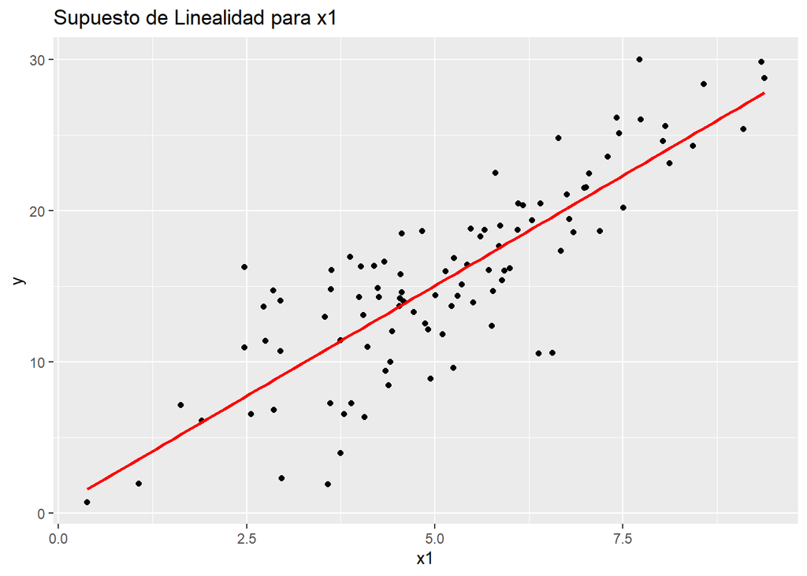

```r
# Verificar los supuestos del Teorema de Gauss-Markov

# 1. Linealidad
ggplot(data, aes(x = x1, y = y)) +
  geom_point() +
  geom_smooth(method = "lm", se = FALSE, color = "red") +
  labs(title = "Supuesto de Linealidad para x1")
```

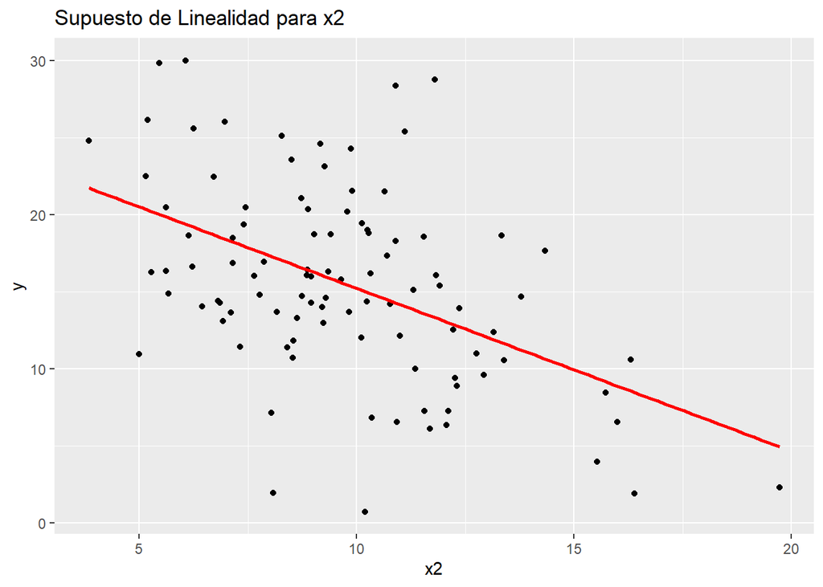

```r
ggplot(data, aes(x = x2, y = y)) +
  geom_point() +
  geom_smooth(method = "lm", se = FALSE, color = "red") +
  labs(title = "Supuesto de Linealidad para x2")
```

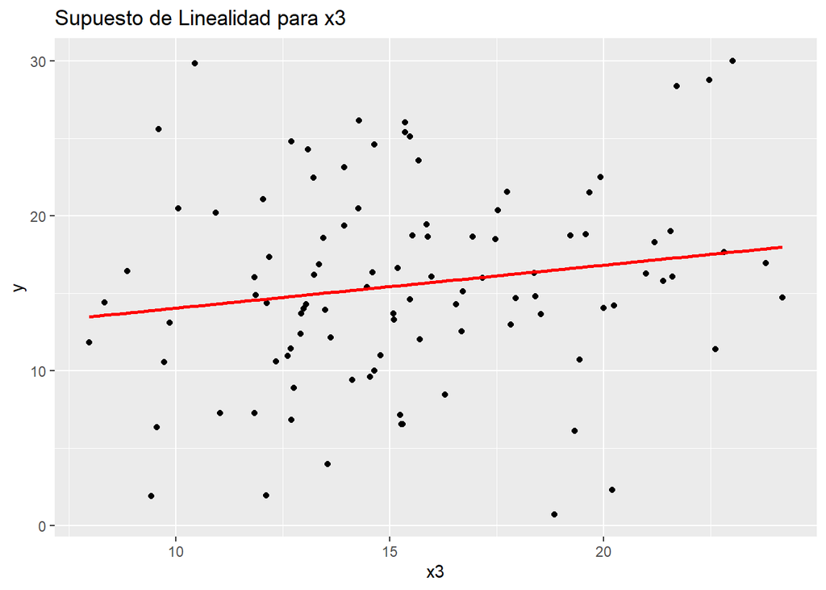

```r
ggplot(data, aes(x = x3, y = y)) +
  geom_point() +
  geom_smooth(method = "lm", se = FALSE, color = "red") +
  labs(title = "Supuesto de Linealidad para x3")
```

```r
# 2. Esperanza cero del error
residuals_mean <- mean(residuals(model))
print(paste("Media de los residuos:", residuals_mean))
```

```
## [1] "Media de los residuos: -2.31271165412883e-17"
```

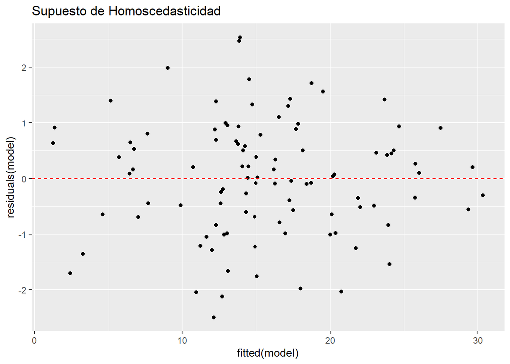

```r
# 3. Homoscedasticidad
ggplot(data, aes(x = fitted(model), y = residuals(model))) +
  geom_point() +
  geom_hline(yintercept = 0, linetype = "dashed", color = "red") +
  labs(title = "Supuesto de Homoscedasticidad")
```

```r
# 4. No multicolinealidad
cor(data[, c("x1", "x2", "x3")])
```

```
##             x1          x2          x3
## x1  1.00000000 -0.04953215 -0.12917601
## x2 -0.04953215  1.00000000  0.03057903
## x3 -0.12917601  0.03057903  1.00000000
```

```r
# Visualizar los resultados del modelo
tidy(model)
```

```
## # A tibble: 4 × 5
##   term        estimate std.error statistic  p.value
##   <chr>          <dbl>     <dbl>     <dbl>    <dbl>
## 1 (Intercept)    2.18     0.672       3.24 1.63e- 3
## 2 x1             2.97     0.0584     50.9  3.11e-71
## 3 x2            -0.985    0.0365    -27.0  1.30e-46
## 4 x3             0.486    0.0281     17.3  2.81e-31
```

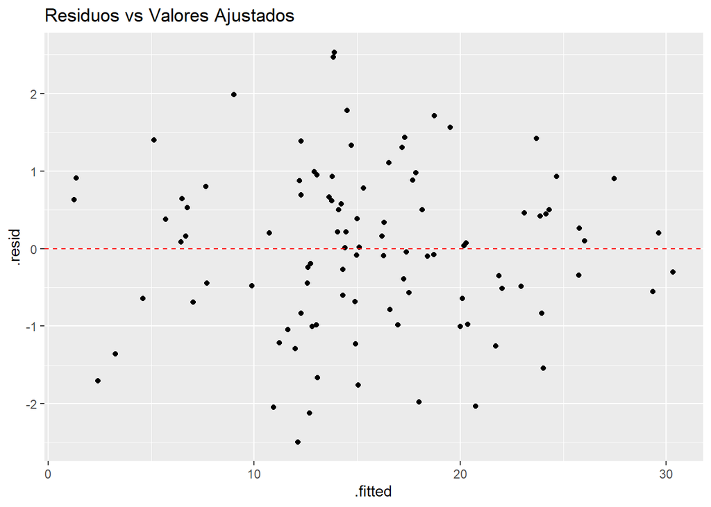

```r
# Visualizar los residuos
augment(model) %>%
  ggplot(aes(x = .fitted, y = .resid)) +
  geom_point() +
  geom_hline(yintercept = 0, linetype = "dashed", color = "red") +
  labs(title = "Residuos vs Valores Ajustados")
```